# Time Series: A First Course with Bootstrap Starter

# Lesson 4-7: Orthonormal Sets

- We extend our discussion to sub-spaces that are linear combinations of infinitely many random variables.
- This is so we can project onto the past of a time series (for forecasting), or onto an entire time series (for imputation or signal extraction).

## Orthonormal Set

- A collection $\{ e_t \}$ where the index set can be ${\mathbb Z}$, has the property that
  $$\langle e_s, e_t \rangle = \begin{cases} 1 \qquad s=t, \\ 0 \qquad s
  \neq t \end{cases}$$

### Examples

- The unit vectors in Euclidean space are orthonormal.
- In ${\mathbb L}_2$, a collection of i.i.d. random variables with variance 1 are orthonormal.

## Closed Linear Span

- We can take the span of a countable collection of random variables, by considering linear combinations.
- If we also include the limits of sequences of such, it is called the *closed linear span*, denoted
  $$\overline{\mbox{sp}} \{ e_t \}$$
- If the basis of the span is finite (i.e., finitely many variables generate the space), then closure is automatic.

## Infinite Projection

- Now we can project onto an infinite set.
- For forecasting, we project $X_{n+1}$ onto $\overline{\mbox{sp}} \{ X_t, t \leq n \}$. This is the orthonormal set of random variables $X_t$ for any $t \leq n$, and then we take the closure.
- For index generation, we project one variable $Y_t$ onto an entire time series $\overline{\mbox{sp}} \{ X_t, t \in {\mathbb Z} \}$.
- For imputation, where the value at time $t$ is missing (an NA), we project $X_t$ onto $\overline{\mbox{sp}} \{ X_s, s \neq t \}$.
- In each case, the unknown target (either a forecast, index, missing value, etc.) is projected onto the information we do have.

### Example 4.7.8. Order Two Autoregression

- Consider an order 2 autoregressive (or AR(2)) process:
  $$X_t = \phi_1 X_{t-1} + \phi_2 X_{t-2} + Z_t$$
  with $Z_t \sim i.i.d. (0, \sigma^2)$. Suppose the recursion is intialized such that the process is stationary.
- We see that $Z_t$ is independent of $X_s$ for all $s < t$.
- The one-step ahead forecast based on the infinite past is denoted $\widehat{X}_{n+1} = P_{ \overline{\mbox{sp}} \{ X_t, t \leq n \} } [X_{n+1}]$.
- Its formula is
  $$\widehat{X}_{n+1} = \phi_1 X_n + \phi_2 X_{n-1},$$
  which is established by verifying the normal equations:
  $$\langle \widehat{X}_{n+1} - X_{n+1}, X_t \rangle = \langle Z_{n+1}, X_t
  \rangle = 0$$
  for $t \leq n$.
- We look at an example with $\phi_1 = .7$ and $\phi_2 = .2$, and $\sigma^2 = 1$.

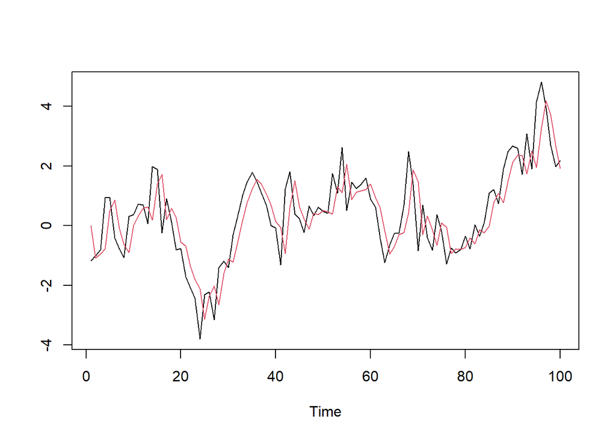

```r
set.seed(123)
n <- 100
phi <- c(.7,.2)
sigma <- 1
Phi <- rbind(phi,c(1,0))
Sigma <- rbind(c(sigma^2,0),c(0,0))
Gam.0 <- solve(diag(4) - Phi %x% Phi,matrix(Sigma,ncol=1))
Gam.0 <- matrix(Gam.0,nrow=2)
Gam.half <- t(chol(Gam.0))
x0 <- Gam.half %*% rnorm(2)
z <- rnorm(n)
xvec <- matrix(0,nrow=2,ncol=n)
xhat <- rep(0,n)
xvec[,1] <- x0
for(t in 2:n)
{
  xvec[,t] <- Phi %*% xvec[,t-1] + c(z[t],0)
  xhat[t] <- sum(phi*xvec[,t-1])
}
plot(ts(xvec[1,]),xlab="Time",ylab="")
lines(ts(xhat),col=2)
```

### Linear Prediction of AR(p) Processes

- The AR(p) process has the equation
  $$X_t = \sum_{j=1}^p \phi_j X_{t-j} + Z_t,$$
  with $Z_t \sim i.i.d. (0, \sigma^2)$. Suppose the recursion is initialized such that the process is stationary.
- The one-step ahead forecast based on the infinite past is denoted $\widehat{X}_{n+1} = P_{ \overline{\mbox{sp}} \{ X_t, t \leq n \} } [X_{n+1}]$.
- Its formula is
  $$\widehat{X}_{n+1} = \sum_{j=1}^p \phi_j X_{t-j},$$
  which is established by verifying the normal equations:
  $$\langle \widehat{X}_{n+1} - X_{n+1}, X_t \rangle = \langle Z_{n+1}, X_t
  \rangle = 0$$
  for $t \leq n$.
- We look at a $p=3$ example with $\phi_1 = .7$, $\phi_2 = .2$, and $\phi_3 = -.2$, and $\sigma^2 = 1$.

```r
set.seed(123)
n <- 100
phi <- c(.7,.2,-.2)
sigma <- 1
Phi <- rbind(phi,c(1,0,0),c(0,1,0))
Mod(eigen(Phi)$values)
```

```
## [1] 0.6324555 0.6324555 0.5000000
```

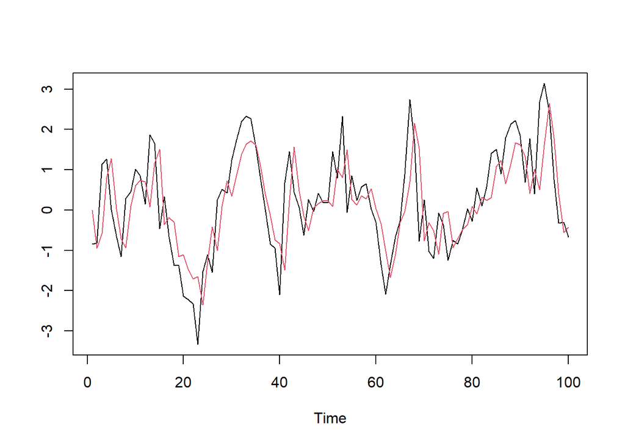

```r
Sigma <- rbind(c(sigma^2,0,0),c(0,0,0),c(0,0,0))
Gam.0 <- solve(diag(9) - Phi %x% Phi,matrix(Sigma,ncol=1))
Gam.0 <- matrix(Gam.0,nrow=3)
Gam.half <- t(chol(Gam.0))
x0 <- Gam.half %*% rnorm(3)
z <- rnorm(n)
xvec <- matrix(0,nrow=3,ncol=n)
xhat <- rep(0,n)
xvec[,1] <- x0
for(t in 2:n)
{
  xvec[,t] <- Phi %*% xvec[,t-1] + c(z[t],0,0)
  xhat[t] <- sum(phi*xvec[,t-1])
}
plot(ts(xvec[1,]),xlab="Time",ylab="")
lines(ts(xhat),col=2)
```